# Problem Statement

## Correlation Matrix

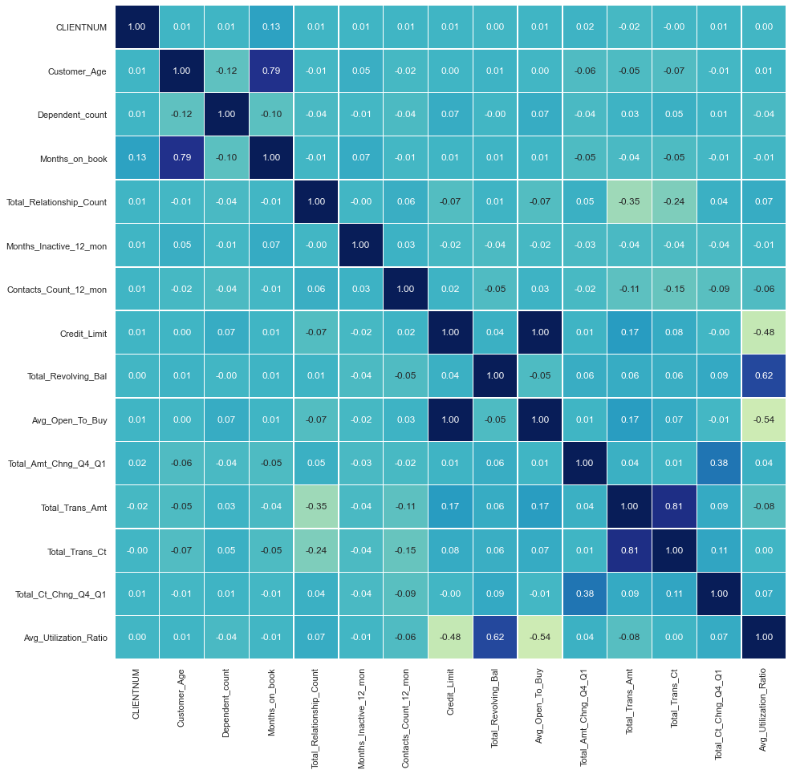

```python
sns.set(rc={"figure.figsize": (15, 15)})
sns.heatmap(
    data.corr(),
    annot=True,
    linewidths=0.5,
    center=0,
    cbar=False,
    cmap="YlGnBu",
    fmt="0.2f",
)
plt.show()
```

## Illustrate the insights based on EDA

- There is huge difference in the credit limit based on card_category. Platinum card has higher credit limit.
- Platinum Card holder have Higher transaction Amount Blue card holders have minimum transaction Amount but with few outlier on the higher end. There is clear relation ship between Transaction_Amount and Card_Category.
- Total_Ct_Chng_Q4_Q1 and Total_Amt_Chng_Q4_Q1 have same distribution pattern.
- Attrition customers are more in Doctorates.
- Attrition is almost similar in all Income_categories.
- Attrition is more in Platinum card category.
- Attrition is slightly more in Dependent_count =3.
- There is good correlation between Total_Trans_amt and Total_trans_Ct. One column can be removed due to multiple corrlation problem.
- There is good correlation between Avg_Open_To_Buy and Credit_Limit. Avg_Open_To_Buy can be removed due to multiple corrlation problem.

## Data Pre-processing

### **Outlier detection**

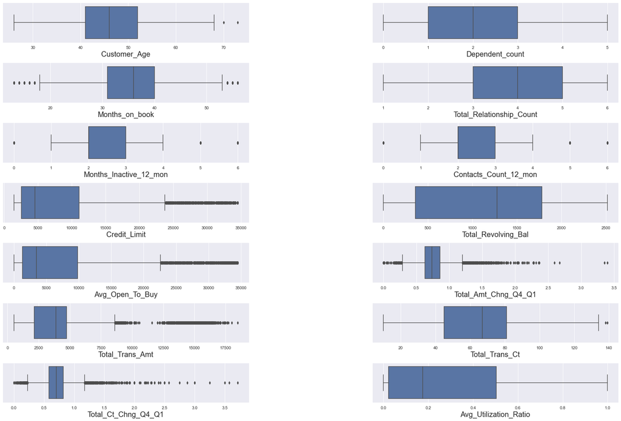

```python
fig, ax_list = plt.subplots(7, 2, figsize=(30,20))  # create 4*2 subplots
fig.subplots_adjust( wspace=0.5, hspace=0.5)    # to increase distance between subplots


row,col = (0,0)
for feature in data.columns[1:]:
    if data[feature].dtype.name != 'object':   # select columns which are not category datatype
        row_count = row
        col_count = col
        g = sns.boxplot(data[feature], ax=ax_list[row_count,col_count])   # boxplot  for given feature
        g.set_xlabel(feature, fontsize = 20)    # set label
        if(col==1):     # logic to set subplot ax for boxplot
            row = row+1
            col = 0
        else:
            col= col+1
plt.show()
```

**Insights from outlier detection**

1. Following features are showing outliers.

   CustomerAge - 2 Outliers towards right  
   Months_on_book - Outliers towards right and left  
   Credit_limit - Outliers towards right  
   Avg_Open_To_Buy - Outliers towards right  
   Total_Amt_Chng_Q4_Q1 - Outliers towards right and left  
   Total_Trans_Amt - Outliers towards right

Outliers in all columns donot look very abnormal. Not removing outliers from the data so that models learns from the data points.

### Missing Values

There are no null values in any of the columns.

### Prepare data for modeling

```python
for feature in data.columns: # Loop through all columns in the dataframe
    if data[feature].dtype == 'object': # Only apply for columns with categorical strings
        data[feature] = pd.Categorical(data[feature])
data.head(10)
```

|  | CLIENTNUM | Attrition_Flag | Customer_Age | Gender | Dependent_count | Education_Level | Marital_Status | Income_Category | Card_Category | Months_on_book | ... | Months_Inactive_12_mon | Contacts_Count_12_mon | Credit_Limit | Total_Revolving_Bal | Avg_Open_To_Buy | Total_Amt_Chng_Q4_Q1 | Total_Trans_Amt | Total_Trans_Ct | Total_Ct_Chng_Q4_Q1 | Avg_Utilization_Ratio |
| --- | --- | --- | --- | --- | --- | --- | --- | --- | --- | --- | --- | --- | --- | --- | --- | --- | --- | --- | --- | --- | --- |
| 0 | 768805383 | Existing Customer | 45 | M | 3 | High School | Married | $60K - $80K | Blue | 39 | ... | 1 | 3 | 12691.0 | 777 | 11914.0 | 1.335 | 1144 | 42 | 1.625 | 0.061 |
| 1 | 818770008 | Existing Customer | 49 | F | 5 | Graduate | Single | Less than $40K | Blue | 44 | ... | 1 | 2 | 8256.0 | 864 | 7392.0 | 1.541 | 1291 | 33 | 3.714 | 0.105 |
| 2 | 713982108 | Existing Customer | 51 | M | 3 | Graduate | Married | $80K - $120K | Blue | 36 | ... | 1 | 0 | 3418.0 | 0 | 3418.0 | 2.594 | 1887 | 20 | 2.333 | 0.000 |
| 3 | 769911858 | Existing Customer | 40 | F | 4 | High School | Unknown | Less than $40K | Blue | 34 | ... | 4 | 1 | 3313.0 | 2517 | 796.0 | 1.405 | 1171 | 20 | 2.333 | 0.760 |
| 4 | 709106358 | Existing Customer | 40 | M | 3 | Uneducated | Married | $60K - $80K | Blue | 21 | ... | 1 | 0 | 4716.0 | 0 | 4716.0 | 2.175 | 816 | 28 | 2.500 | 0.000 |
| 5 | 713061558 | Existing Customer | 44 | M | 2 | Graduate | Married | $40K - $60K | Blue | 36 | ... | 1 | 2 | 4010.0 | 1247 | 2763.0 | 1.376 | 1088 | 24 | 0.846 | 0.311 |
| 6 | 810347208 | Existing Customer | 51 | M | 4 | Unknown | Married | $120K + | Gold | 46 | ... | 1 | 3 | 34516.0 | 2264 | 32252.0 | 1.975 | 1330 | 31 | 0.722 | 0.066 |
| 7 | 818906208 | Existing Customer | 32 | M | 0 | High School | Unknown | $60K - $80K | Silver | 27 | ... | 2 | 2 | 29081.0 | 1396 | 27685.0 | 2.204 | 1538 | 36 | 0.714 | 0.048 |
| 8 | 710930508 | Existing Customer | 37 | M | 3 | Uneducated | Single | $60K - $80K | Blue | 36 | ... | 2 | 0 | 22352.0 | 2517 | 19835.0 | 3.355 | 1350 | 24 | 1.182 | 0.113 |
| 9 | 719661558 | Existing Customer | 48 | M | 2 | Graduate | Single | $80K - $120K | Blue | 36 | ... | 3 | 3 | 11656.0 | 1677 | 9979.0 | 1.524 | 1441 | 32 | 0.882 | 0.144 |

10 rows × 21 columns

```python
data.dtypes
```

```
CLIENTNUM                      int64
Attrition_Flag              category
Customer_Age                   int64
Gender                      category
Dependent_count                int64
Education_Level             category
Marital_Status              category
Income_Category             category
Card_Category               category
Months_on_book                 int64
Total_Relationship_Count       int64
Months_Inactive_12_mon         int64
Contacts_Count_12_mon          int64
Credit_Limit                 float64
Total_Revolving_Bal            int64
Avg_Open_To_Buy              float64
Total_Amt_Chng_Q4_Q1         float64
Total_Trans_Amt                int64
Total_Trans_Ct                 int64
Total_Ct_Chng_Q4_Q1          float64
Avg_Utilization_Ratio        float64
dtype: object
```

### One_hot Encoding

```python
replaceStruct = {
                 "Attrition_Flag": {"Attrited Customer":1, "Existing Customer":0},
                "Gender": {"F":1, "M":0},
                 "Income_Category": {"Less than $40K": 1, "$40K - $60K":2 ,"$60K - $80K":3 ,"$80K - $120K":4 ,"$120K +":5, "Unknown":-1},
                    }
oneHotCols=["Card_Category","Marital_Status","Education_Level"]
```

```python
data=data.replace(replaceStruct)
data=pd.get_dummies(data, columns=oneHotCols)
data.head(10)
```

|  | CLIENTNUM | Attrition_Flag | Customer_Age | Gender | Dependent_count | Income_Category | Months_on_book | Total_Relationship_Count | Months_Inactive_12_mon | Contacts_Count_12_mon | ... | Marital_Status_Married | Marital_Status_Single | Marital_Status_Unknown | Education_Level_College | Education_Level_Doctorate | Education_Level_Graduate | Education_Level_High School | Education_Level_Post-Graduate | Education_Level_Uneducated | Education_Level_Unknown |
| --- | --- | --- | --- | --- | --- | --- | --- | --- | --- | --- | --- | --- | --- | --- | --- | --- | --- | --- | --- | --- | --- |
| 0 | 768805383 | 0 | 45 | 0 | 3 | 3 | 39 | 5 | 1 | 3 | ... | 1 | 0 | 0 | 0 | 0 | 0 | 1 | 0 | 0 | 0 |
| 1 | 818770008 | 0 | 49 | 1 | 5 | 1 | 44 | 6 | 1 | 2 | ... | 0 | 1 | 0 | 0 | 0 | 1 | 0 | 0 | 0 | 0 |
| 2 | 713982108 | 0 | 51 | 0 | 3 | 4 | 36 | 4 | 1 | 0 | ... | 1 | 0 | 0 | 0 | 0 | 1 | 0 | 0 | 0 | 0 |
| 3 | 769911858 | 0 | 40 | 1 | 4 | 1 | 34 | 3 | 4 | 1 | ... | 0 | 0 | 1 | 0 | 0 | 0 | 1 | 0 | 0 | 0 |
| 4 | 709106358 | 0 | 40 | 0 | 3 | 3 | 21 | 5 | 1 | 0 | ... | 1 | 0 | 0 | 0 | 0 | 0 | 0 | 0 | 1 | 0 |
| 5 | 713061558 | 0 | 44 | 0 | 2 | 2 | 36 | 3 | 1 | 2 | ... | 1 | 0 | 0 | 0 | 0 | 1 | 0 | 0 | 0 | 0 |
| 6 | 810347208 | 0 | 51 | 0 | 4 | 5 | 46 | 6 | 1 | 3 | ... | 1 | 0 | 0 | 0 | 0 | 0 | 0 | 0 | 0 | 1 |
| 7 | 818906208 | 0 | 32 | 0 | 0 | 3 | 27 | 2 | 2 | 2 | ... | 0 | 0 | 1 | 0 | 0 | 0 | 1 | 0 | 0 | 0 |
| 8 | 710930508 | 0 | 37 | 0 | 3 | 3 | 36 | 5 | 2 | 0 | ... | 0 | 1 | 0 | 0 | 0 | 0 | 0 | 0 | 1 | 0 |
| 9 | 719661558 | 0 | 48 | 0 | 2 | 4 | 36 | 6 | 3 | 3 | ... | 0 | 1 | 0 | 0 | 0 | 1 | 0 | 0 | 0 | 0 |

10 rows × 33 columns

```python
data.dtypes
```

```
CLIENTNUM                          int64
Attrition_Flag                     int64
Customer_Age                       int64
Gender                             int64
Dependent_count                    int64
Income_Category                    int64
Months_on_book                     int64
Total_Relationship_Count           int64
Months_Inactive_12_mon             int64
Contacts_Count_12_mon              int64
Credit_Limit                     float64
Total_Revolving_Bal                int64
Avg_Open_To_Buy                  float64
Total_Amt_Chng_Q4_Q1             float64
Total_Trans_Amt                    int64
Total_Trans_Ct                     int64
Total_Ct_Chng_Q4_Q1              float64
Avg_Utilization_Ratio            float64
Card_Category_Blue                 uint8
Card_Category_Gold                 uint8
Card_Category_Platinum             uint8
Card_Category_Silver               uint8
Marital_Status_Divorced            uint8
Marital_Status_Married             uint8
Marital_Status_Single              uint8
Marital_Status_Unknown             uint8
Education_Level_College            uint8
Education_Level_Doctorate          uint8
Education_Level_Graduate           uint8
Education_Level_High School        uint8
Education_Level_Post-Graduate      uint8
Education_Level_Uneducated         uint8
Education_Level_Unknown            uint8
dtype: object
```

```python
data['Attrition_Flag'] = pd.Categorical(data['Attrition_Flag'])
data.head()
```

|  | CLIENTNUM | Attrition_Flag | Customer_Age | Gender | Dependent_count | Income_Category | Months_on_book | Total_Relationship_Count | Months_Inactive_12_mon | Contacts_Count_12_mon | ... | Marital_Status_Married | Marital_Status_Single | Marital_Status_Unknown | Education_Level_College | Education_Level_Doctorate | Education_Level_Graduate | Education_Level_High School | Education_Level_Post-Graduate | Education_Level_Uneducated | Education_Level_Unknown |
| --- | --- | --- | --- | --- | --- | --- | --- | --- | --- | --- | --- | --- | --- | --- | --- | --- | --- | --- | --- | --- | --- |
| 0 | 768805383 | 0 | 45 | 0 | 3 | 3 | 39 | 5 | 1 | 3 | ... | 1 | 0 | 0 | 0 | 0 | 0 | 1 | 0 | 0 | 0 |
| 1 | 818770008 | 0 | 49 | 1 | 5 | 1 | 44 | 6 | 1 | 2 | ... | 0 | 1 | 0 | 0 | 0 | 1 | 0 | 0 | 0 | 0 |
| 2 | 713982108 | 0 | 51 | 0 | 3 | 4 | 36 | 4 | 1 | 0 | ... | 1 | 0 | 0 | 0 | 0 | 1 | 0 | 0 | 0 | 0 |
| 3 | 769911858 | 0 | 40 | 1 | 4 | 1 | 34 | 3 | 4 | 1 | ... | 0 | 0 | 1 | 0 | 0 | 0 | 1 | 0 | 0 | 0 |
| 4 | 709106358 | 0 | 40 | 0 | 3 | 3 | 21 | 5 | 1 | 0 | ... | 1 | 0 | 0 | 0 | 0 | 0 | 0 | 0 | 1 | 0 |

5 rows × 33 columns

```python
data.dtypes
```

```
CLIENTNUM                           int64
Attrition_Flag                   category
Customer_Age                        int64
Gender                              int64
Dependent_count                     int64
Income_Category                     int64
Months_on_book                      int64
Total_Relationship_Count            int64
Months_Inactive_12_mon              int64
Contacts_Count_12_mon               int64
Credit_Limit                      float64
Total_Revolving_Bal                 int64
Avg_Open_To_Buy                   float64
Total_Amt_Chng_Q4_Q1              float64
Total_Trans_Amt                     int64
Total_Trans_Ct                      int64
Total_Ct_Chng_Q4_Q1               float64
Avg_Utilization_Ratio             float64
Card_Category_Blue                  uint8
Card_Category_Gold                  uint8
Card_Category_Platinum              uint8
Card_Category_Silver                uint8
Marital_Status_Divorced             uint8
Marital_Status_Married              uint8
Marital_Status_Single               uint8
Marital_Status_Unknown              uint8
Education_Level_College             uint8
Education_Level_Doctorate           uint8
Education_Level_Graduate            uint8
Education_Level_High School         uint8
Education_Level_Post-Graduate       uint8
Education_Level_Uneducated          uint8
Education_Level_Unknown             uint8
dtype: object
```

### Feature Engineering

```python
# Total_trans_Ct,Avg_Open_To_Buy are removed as they have high correlaion with Total_Trans_amt and Credit_Limit respectively.

# CLIENTNUM is dropped as it is customer id.

data = data.drop(["CLIENTNUM","Avg_Open_To_Buy"], axis=1)
data = data.drop(["Total_Trans_Ct"], axis=1)
```

```python
data.info()
```

```
<class 'pandas.core.frame.DataFrame'>
RangeIndex: 10127 entries, 0 to 10126
Data columns (total 30 columns):
 #   Column                         Non-Null Count  Dtype
---  ------                         --------------  -----
 0   Attrition_Flag                 10127 non-null  category
 1   Customer_Age                   10127 non-null  int64
 2   Gender                         10127 non-null  int64
 3   Dependent_count                10127 non-null  int64
 4   Income_Category                10127 non-null  int64
 5   Months_on_book                 10127 non-null  int64
 6   Total_Relationship_Count       10127 non-null  int64
 7   Months_Inactive_12_mon         10127 non-null  int64
 8   Contacts_Count_12_mon          10127 non-null  int64
 9   Credit_Limit                   10127 non-null  float64
```

[output cut: 22 more lines]

Go to index

## Split the dataset

```python
# Separating target variable and other variables
X = data.drop(columns="Attrition_Flag")
y = data["Attrition_Flag"]
```

```python
# Splitting the data into train and test sets
X_train, X_test, y_train, y_test = train_test_split(
    X, y, test_size=0.30, random_state=1, stratify=y
)
print(X_train.shape, X_test.shape)
```

```
(7088, 29) (3039, 29)
```

```python
y.value_counts()
```

```
0    8500
1    1627
Name: Attrition_Flag, dtype: int64
```

Go to index

## Model building

### Model Evaluation Criterion

**Objective**: Bank wants to analyze the data of customers’ and **identify the customers who will leave their credit card services** and reason for same – so that bank could improve upon those areas.

**Analysis**: Here attrition (i.e who will leave the credit card service is considered as 1)

Customers who are predicted will leave but in real they did not leave - False Positive  
Customers who are predicted as not leave but in real they will leave - False Negative

Customers leaving the offer would lead to more loss.

As per the bank requirement - Decreasing False Negatives is important. so that we can capture most of the customers who could potentially leave the credit card services. and act to take suitable steps to hold these customers.

which means RECALL scoring metrics is more important for this problem.

```python
## Function to draw confusion matrix
def draw_confusion_matrix(model,y_actual,labels=[1, 0]):
    '''
    model : model classifier
    y_actual : ground truth

    '''
    y_predict = model.predict(X_test)  # get predictions for given test data
    cm=metrics.confusion_matrix( y_actual, y_predict, labels=[0, 1])   # call confusion matrix function
    df_cm = pd.DataFrame(cm, index = [i for i in ["Actual - No","Actual - Yes"]],
                  columns = [i for i in ['Predicted - No','Predicted - Yes']])    # define pandas df with required index and columns
    group_counts = ["{0:0.0f}".format(value) for value in
                cm.flatten()]
    group_percentages = ["{0:.2%}".format(value) for value in
                         cm.flatten()/np.sum(cm)]       # calculate TP,FP,TN,FN percentages
    labels = [f"{v1}\n{v2}" for v1, v2 in
              zip(group_counts,group_percentages)]
    labels = np.asarray(labels).reshape(2,2)
    plt.figure(figsize = (10,7))   # set figure size
    sns.heatmap(df_cm, annot=labels,fmt='')   # draw heat map
    plt.ylabel('True label')       # set y label
    plt.xlabel('Predicted label')  # set x label
```

```python
##  Function to calculate different metric scores of the model - Accuracy, Recall and Precision
def get_metrics_score(model,train,test,train_y,test_y,flag=True):
    '''
    model : classifier to predict values of X

    '''
    # defining an empty list to store train and test results
    score_list=[]

    pred_train = model.predict(train)
    pred_test = model.predict(test)

    train_acc = model.score(train,train_y)
    test_acc = model.score(test,test_y)

    train_recall = metrics.recall_score(train_y,pred_train)
    test_recall = metrics.recall_score(test_y,pred_test)

    train_precision = metrics.precision_score(train_y,pred_train)
    test_precision = metrics.precision_score(test_y,pred_test)

    score_list.extend((train_acc,test_acc,train_recall,test_recall,train_precision,test_precision))

    # If the flag is set to True then only the following print statements will be dispayed. The default value is set to True.
    if flag == True:
        print("Accuracy on training set : ",model.score(train,train_y))
        print("Accuracy on test set : ",model.score(test,test_y))
        print("Recall on training set : ",metrics.recall_score(train_y,pred_train))
        print("Recall on test set : ",metrics.recall_score(test_y,pred_test))
        print("Precision on training set : ",metrics.precision_score(train_y,pred_train))
        print("Precision on test set : ",metrics.precision_score(test_y,pred_test))

    return score_list # returning the list with train and test scores
```

## Logistic Regression

### Simple Logistic Regression

```python
# pipeline definition for Logistic Regression
LR1= Pipeline(
            steps=[
                ("scaler", StandardScaler()),
                ("log_reg", LogisticRegression(random_state=1)),
            ]
        )
scoring = "recall"


LR1.fit(X_train,y_train)
```

```
Pipeline(steps=[('scaler', StandardScaler()),
                ('log_reg', LogisticRegression(random_state=1))])
```

### Logistic Regression with Upsampling

```python
sm = SMOTE(sampling_strategy = 1 ,k_neighbors = 5, random_state=1)   #Synthetic Minority Over Sampling Technique

print("Before UpSampling, counts of label 'Yes': {}".format(sum(y_train==1)))
print("Before UpSampling, counts of label 'No': {} \n".format(sum(y_train==0)))

X_train_over, y_train_over = sm.fit_resample(X_train, y_train.ravel())

print("After UpSampling, counts of label 'Yes': {}".format(sum(y_train_over==1)))
print("After UpSampling, counts of label 'No': {} \n".format(sum(y_train_over==0)))


print('After UpSampling, the shape of train_X: {}'.format(X_train_over.shape))
print('After UpSampling, the shape of train_y: {} \n'.format(y_train_over.shape))
LR2= Pipeline(
            steps=[
                ("scaler", StandardScaler()),
                ("log_reg", LogisticRegression(random_state=1)),
            ]
        )


LR2.fit(X_train_over,y_train_over)
```

```
Before UpSampling, counts of label 'Yes': 1139
Before UpSampling, counts of label 'No': 5949

After UpSampling, counts of label 'Yes': 5949
After UpSampling, counts of label 'No': 5949

After UpSampling, the shape of train_X: (11898, 29)
After UpSampling, the shape of train_y: (11898,)
```

```
Pipeline(steps=[('scaler', StandardScaler()),
                ('log_reg', LogisticRegression(random_state=1))])
```

### Logistic Regression with DownSampling

```python
tl = TomekLinks()

print("Before DownSampling, counts of label 'Yes': {}".format(sum(y_train==1)))
print("Before DownSampling, counts of label 'No': {} \n".format(sum(y_train==0)))

X_train_down, y_train_down= tl.fit_resample(X_train, y_train)


print("After UpSampling, counts of label 'Yes': {}".format(sum(y_train_down==1)))
print("After UpSampling, counts of label 'No': {} \n".format(sum(y_train_down==0)))


print('After UpSampling, the shape of train_X: {}'.format(X_train_down.shape))
print('After UpSampling, the shape of train_y: {} \n'.format(y_train_down.shape))
LR3= Pipeline(
            steps=[
                ("scaler", StandardScaler()),
                ("log_reg", LogisticRegression(random_state=1)),
            ]
        )


LR3.fit(X_train_down,y_train_down)
```

```
Before DownSampling, counts of label 'Yes': 1139
Before DownSampling, counts of label 'No': 5949

After UpSampling, counts of label 'Yes': 1139
After UpSampling, counts of label 'No': 5688

After UpSampling, the shape of train_X: (6827, 29)
After UpSampling, the shape of train_y: (6827,)
```

```
Pipeline(steps=[('scaler', StandardScaler()),
                ('log_reg', LogisticRegression(random_state=1))])
```

### Logistic Regression with Upsampling,Regularization

```python
#Upsampling and Regularization

sm = SMOTE(sampling_strategy = 1 ,k_neighbors = 5, random_state=1)   #Synthetic Minority Over Sampling Technique
X_train_over, y_train_over = sm.fit_resample(X_train, y_train.ravel())
LR4= Pipeline(
            steps=[
                ("scaler", StandardScaler()),
                ("log_reg", LogisticRegression(random_state=1,solver='saga')),
            ]
        )

# Grid of parameters to choose from
parameters = {'log_reg__C': np.arange(0.1,1.1,0.1)}
    # Inverse of regularization strength; must be a positive float.
    # Smaller values specify stronger regularization.

# Run the grid search
grid_obj = GridSearchCV(LR4, parameters, scoring='recall')
grid_obj = grid_obj.fit(X_train_over, y_train_over)

# Set the clf to the best combination of parameters
LR4 = grid_obj.best_estimator_

# Fit the best algorithm to the data.
LR4.fit(X_train_over, y_train_over)
```

```
Pipeline(steps=[('scaler', StandardScaler()),
                ('log_reg',
                 LogisticRegression(C=0.4, random_state=1, solver='saga'))])
```

```python
# Calculating Cross Validation Scores for all Logistic Regression Models

scoring='recall'
kfold=StratifiedKFold(n_splits=5,shuffle=True,random_state=1)
LR_models = [LR1,LR2,LR3,LR4]

lr_cv_results =[]

cv_score1 =cross_val_score(estimator=LR1, X=X_train, y=y_train, scoring=scoring, cv=kfold)
lr_cv_results.append (cv_score1.mean())

cv_score2 =cross_val_score(estimator=LR2, X=X_train_over, y=y_train_over, scoring=scoring, cv=kfold)
lr_cv_results.append (cv_score2.mean())

cv_score3 =cross_val_score(estimator=LR3, X=X_train_down, y=y_train_down, scoring=scoring, cv=kfold)
lr_cv_results.append (cv_score3.mean())

cv_score4 =cross_val_score(estimator=LR4, X=X_train_over, y=y_train_over, scoring=scoring, cv=kfold)
lr_cv_results.append (cv_score4.mean())

lr_cv_results
```

```
[0.4310997758713966, 0.8732562495141034, 0.4468428781204111, 0.872919973708575]
```

```python
comparison_frame = pd.DataFrame(
    {
        "Model": [
            "Simple Logistic Regression",
            "Logistic Regression with UpSampling",
            "Logistic Regression with DownSampling",
            "Logistic Regression with UpSampling, Regularization"
        ],
        "cv_recall_results": lr_cv_results
    }
)

comparison_frame
# Sorting models in decreasing order of test recall
#comparison_frame.sort_values(by="cv_recall_results", ascending=False)
```

|  | Model | cv_recall_results |
| --- | --- | --- |
| 0 | Simple Logistic Regression | 0.431100 |
| 1 | Logistic Regression with UpSampling | 0.873256 |
| 2 | Logistic Regression with DownSampling | 0.446843 |
| 3 | Logistic Regression with UpSampling, Regulariz... | 0.872920 |

### Comparing all Logistic Regression models

```python
# defining list of models
lr_models = [LR1,LR2,LR3,LR4]

# defining empty lists to add train and test results
acc_train = []
acc_test = []
recall_train = []
recall_test = []
precision_train = []
precision_test = []

# looping through all the models to get the metrics score - Accuracy, Recall and Precision
for model in lr_models:
    X_train, X_test, y_train, y_test
    if model==LR1:
        j = get_metrics_score(model,X_train,X_test,y_train,y_test,False)
    if model==LR2:
        j = get_metrics_score(model,X_train_over,X_test,y_train_over,y_test,False)
    if model==LR3:
        j = get_metrics_score(model,X_train_down,X_test,y_train_down,y_test,False)
    if model==LR4:
        j = get_metrics_score(model,X_train_over,X_test,y_train_over,y_test,False)
    acc_train.append(j[0])
    acc_test.append(j[1])
    recall_train.append(j[2])
    recall_test.append(j[3])
    precision_train.append(j[4])
    precision_test.append(j[5])
```

```python
comparison_frame_lr_models = pd.DataFrame(
    {
        "Model": [
            "Simple Logistic Regression",
            "Logistic Regression with Upsampling",
            "Logistic Regression with DownSampling",
            "Logistic Regression with Upsampling,Regularization",

        ],
        "Train_Accuracy": acc_train,
        "Test_Accuracy": acc_test,
        "Train_Recall": recall_train,
        "Test_Recall": recall_test,
        "Train_Precision": precision_train,
        "Test_Precision": precision_test,
        "Cross_Validation_Scores":lr_cv_results
    }
)

# Sorting models in decreasing order of test recall
comparison_frame_lr_models.sort_values(by="Test_Recall", ascending=False)
```

|  | Model | Train_Accuracy | Test_Accuracy | Train_Recall | Test_Recall | Train_Precision | Test_Precision | Cross_Validation_Scores |
| --- | --- | --- | --- | --- | --- | --- | --- | --- |
| 1 | Logistic Regression with Upsampling | 0.919482 | 0.886476 | 0.874937 | 0.469262 | 0.960509 | 0.726984 | 0.873256 |
| 3 | Logistic Regression with Upsampling,Regulariza... | 0.918894 | 0.886476 | 0.873928 | 0.467213 | 0.960288 | 0.728435 | 0.872920 |
| 2 | Logistic Regression with DownSampling | 0.888970 | 0.887134 | 0.453029 | 0.436475 | 0.792627 | 0.758007 | 0.446843 |
| 0 | Simple Logistic Regression | 0.889391 | 0.885818 | 0.430202 | 0.409836 | 0.784000 | 0.772201 | 0.431100 |

### Insights from Logistic Regression Metircs.

1. Test Recall scores are low for all different LR models. Need to test if we can improve with other algorithms.
2. Simple Logistic Regression shows less over fit.
3. Logistic Regression with Upsampling and Regularization show over fit of data.

```python
## Feature Importance or Coefficients
fi = pd.DataFrame()
fi['Col'] = X_train_over.columns
fi['Coeff'] = np.round(abs(LR2['log_reg'].coef_[0]),5)
fi.sort_values(by='Coeff',ascending=False).T
```

|  | 19 | 24 | 20 | 25 | 28 | 27 | 22 | 14 | 18 | 21 | ... | 6 | 16 | 13 | 8 | 3 | 10 | 0 | 2 | 4 | 1 |
| --- | --- | --- | --- | --- | --- | --- | --- | --- | --- | --- | --- | --- | --- | --- | --- | --- | --- | --- | --- | --- | --- |
| Col | Marital_Status_Married | Education_Level_Graduate | Marital_Status_Single | Education_Level_High School | Education_Level_Unknown | Education_Level_Uneducated | Education_Level_College | Card_Category_Blue | Marital_Status_Divorced | Marital_Status_Unknown | ... | Months_Inactive_12_mon | Card_Category_Platinum | Avg_Utilization_Ratio | Credit_Limit | Income_Category | Total_Amt_Chng_Q4_Q1 | Customer_Age | Dependent_count | Months_on_book | Gender |
| Coeff | 3.03619 | 2.9637 | 2.86018 | 2.44427 | 2.13198 | 2.12502 | 1.82299 | 1.56002 | 1.33796 | 1.31179 | ... | 0.32935 | 0.15817 | 0.15053 | 0.12051 | 0.04647 | 0.04435 | 0.01509 | 0.01358 | 0.01207 | 0.00135 |

2 rows × 29 columns

Go to index

```python
## Feature Importance or Coefficients after Regularization.
fi = pd.DataFrame()
fi['Col'] = X_train_over.columns
fi['Coeff'] = np.round(abs(LR4['log_reg'].coef_[0]),5)
fi.sort_values(by='Coeff',ascending=False).T
#Regularization

#fi.sort_values(by='Coeff',ascending=False)
```

|  | 24 | 19 | 20 | 25 | 28 | 27 | 22 | 14 | 18 | 21 | ... | 6 | 13 | 16 | 8 | 3 | 10 | 1 | 0 | 4 | 2 |
| --- | --- | --- | --- | --- | --- | --- | --- | --- | --- | --- | --- | --- | --- | --- | --- | --- | --- | --- | --- | --- | --- |
| Col | Education_Level_Graduate | Marital_Status_Married | Marital_Status_Single | Education_Level_High School | Education_Level_Unknown | Education_Level_Uneducated | Education_Level_College | Card_Category_Blue | Marital_Status_Divorced | Marital_Status_Unknown | ... | Months_Inactive_12_mon | Avg_Utilization_Ratio | Card_Category_Platinum | Credit_Limit | Income_Category | Total_Amt_Chng_Q4_Q1 | Gender | Customer_Age | Months_on_book | Dependent_count |
| Coeff | 2.57411 | 2.56563 | 2.40882 | 2.12264 | 1.85349 | 1.84961 | 1.59136 | 1.24475 | 1.13758 | 1.10701 | ... | 0.32417 | 0.15111 | 0.11956 | 0.11695 | 0.05754 | 0.04209 | 0.01459 | 0.01431 | 0.01031 | 0.00925 |

2 rows × 29 columns

**With regularization, the coefficients have reduced to some extent** The model became slightly generalized. we can see slight decrease in metrics when compared to model(Logistic Regression with Upsampling).

Go to index

## Model building - Bagging and Boosting

### Bagging and Boosting

```python
models = []  # Empty list to store all the models

# Appending pipelines for each model into the list
models.append(
    (
        "DTREE",
        Pipeline(
            steps=[
                ("scaler", StandardScaler()),
                ("decision_tree", DecisionTreeClassifier(random_state=1)),
            ]
        ),
    )
)


models.append(
    (
        "RF",
        Pipeline(
            steps=[
                ("scaler", StandardScaler()),
                ("random_forest", RandomForestClassifier(random_state=1)),
            ]
        ),
    )
)


models.append(
    (
        "BAG",
        Pipeline(
            steps=[
                ("scaler", StandardScaler()),
                ("bagging_classifier", BaggingClassifier(random_state=1)),
            ]
        ),
    )
)


models.append(
    (
        "GBM",
        Pipeline(
            steps=[
                ("scaler", StandardScaler()),
                ("gradient_boosting", GradientBoostingClassifier(random_state=1)),
            ]
        ),
    )
)





models.append(
    (
        "ADB",
        Pipeline(
            steps=[
                ("scaler", StandardScaler()),
                ("adaboost", AdaBoostClassifier(random_state=1)),
            ]
        ),
    )
)



models.append(
    (
        "XGB",
        Pipeline(
            steps=[
                ("scaler", StandardScaler()),
                ("xgboost", XGBClassifier(random_state=1,eval_metric='logloss')),
            ]
        ),
    )
)



cv_results = []  # Empty list to store all model's CV scores
names = []  # Empty list to store name of the models

# loop through all models to get the mean cross validated score
for name, model in models:
    scoring = "recall"

    kfold = StratifiedKFold(
        n_splits=3, shuffle=True, random_state=1)  # Setting number of splits equal to 5

    cv_result = cross_val_score(
        estimator=model, X=X_train, y=y_train, scoring=scoring, cv=kfold)

    cv_results.append(cv_result.mean())


    names.append(name)

    print("{}: {}".format(name, cv_result.mean() * 100))
```

```
DTREE: 73.13197241123918
RF: 67.33902698699255
BAG: 74.71068833032449
GBM: 76.82081192426978
ADB: 75.06550016201453
XGB: 81.91177151321577
```

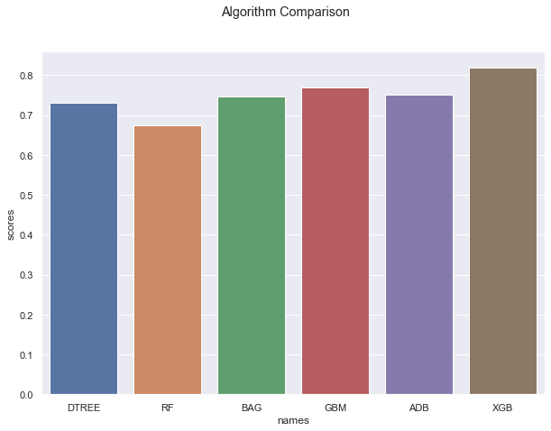

```python
# Plotting barplots for CV scores of all models defined above
fig = plt.figure(figsize=(10, 7))

pdf = {'names': names, 'scores': cv_results}
results_pdf = pd.DataFrame(data=pdf)
results_pdf

fig.suptitle("Algorithm Comparison")


sns.barplot(x="names", y= 'scores', data=results_pdf, orient="vertical")
```

```python
# defining empty lists to add train and test results
acc_train = []
acc_test = []
recall_train = []
recall_test = []
precision_train = []
precision_test = []

# looping through all the models to get the metrics score - Accuracy, Recall and Precision
for name,model in models:
    X_train, X_test, y_train, y_test
    model.fit(X_train, y_train)
    j = get_metrics_score(model,X_train,X_test,y_train,y_test,False)
    acc_train.append(j[0])
    acc_test.append(j[1])
    recall_train.append(j[2])
    recall_test.append(j[3])
    precision_train.append(j[4])
    precision_test.append(j[5])
```

```python
comparison_frame_models = pd.DataFrame(
    {
        "Model": [
            "decision_tree",
            "random_forest",
            "bagging_classifier",
            "gradient_boosting",
            "adaboost",
            "xgboost"
        ],
        "Train_Accuracy": acc_train,
        "Test_Accuracy": acc_test,
        "Train_Recall": recall_train,
        "Test_Recall": recall_test,
        "Train_Precision": precision_train,
        "Test_Precision": precision_test,
        "Cross_Validation_Scores":cv_results
    }
)

# Sorting models in decreasing order of test recall
comparison_frame_models.sort_values(by="Test_Recall", ascending=False)
```

|  | Model | Train_Accuracy | Test_Accuracy | Train_Recall | Test_Recall | Train_Precision | Test_Precision | Cross_Validation_Scores |
| --- | --- | --- | --- | --- | --- | --- | --- | --- |
| 5 | xgboost | 1.000000 | 0.967753 | 1.000000 | 0.875000 | 1.000000 | 0.920259 | 0.819118 |
| 3 | gradient_boosting | 0.963600 | 0.958868 | 0.827919 | 0.797131 | 0.938308 | 0.937349 | 0.768208 |
| 2 | bagging_classifier | 0.996191 | 0.949984 | 0.982441 | 0.778689 | 0.993783 | 0.896226 | 0.747107 |
| 0 | decision_tree | 1.000000 | 0.926621 | 1.000000 | 0.752049 | 1.000000 | 0.782516 | 0.731320 |
| 4 | adaboost | 0.939898 | 0.935176 | 0.759438 | 0.727459 | 0.850541 | 0.847255 | 0.750655 |
| 1 | random_forest | 1.000000 | 0.945377 | 1.000000 | 0.715164 | 1.000000 | 0.928191 | 0.673390 |

Go to index

## Hyperparameter tuning using grid search

### Decision Tree

```python
%%time

dTree_tuned_gs_pipe = Pipeline(
            steps=[
                ("scaler", StandardScaler()),
                ("decision_tree", DecisionTreeClassifier(random_state=1)),
            ]
        )

# Grid of parameters to choose
parameters = {'decision_tree__class_weight': [{0: 0.2, 1: 0.8}],
              'decision_tree__max_depth': np.arange(1,10),
              'decision_tree__min_samples_leaf': [ 10,15,20,25,30],
              'decision_tree__max_leaf_nodes' : [2, 3, 5, 10],
              'decision_tree__min_impurity_decrease': [0.001,0.01,0.1]
             }

# Type of scoring used to compare parameter combinations
acc_scorer = metrics.make_scorer(metrics.recall_score)

# Run the grid search
grid_obj = GridSearchCV(dTree_tuned_gs_pipe, parameters, scoring=acc_scorer,cv=5)
grid_obj = grid_obj.fit(X_train, y_train)

# Set the clf to the best combination of parameters
dTree_tuned_gs = grid_obj.best_estimator_

# Fit the best algorithm to the data.
dTree_tuned_gs.fit(X_train, y_train)
```

```
CPU times: user 46.3 s, sys: 1.44 s, total: 47.8 s
Wall time: 46.7 s
```

```
Pipeline(steps=[('scaler', StandardScaler()),
                ('decision_tree',
                 DecisionTreeClassifier(class_weight={0: 0.2, 1: 0.8},
                                        max_depth=4, max_leaf_nodes=10,
                                        min_impurity_decrease=0.001,
                                        min_samples_leaf=30, random_state=1))])
```

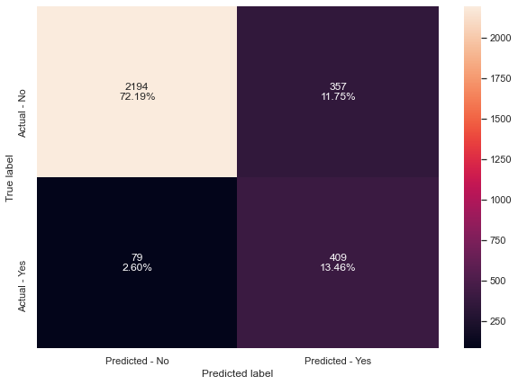

```python
draw_confusion_matrix(dTree_tuned_gs,y_test)
```

```python
dTree_tuned_gs_score = get_metrics_score(dTree_tuned_gs,X_train,X_test,y_train,y_test)
```

```
Accuracy on training set :  0.8654063205417607
Accuracy on test set :  0.8565317538664035
Recall on training set :  0.8577699736611062
Recall on test set :  0.8381147540983607
Precision on training set :  0.5522894290559638
Precision on test set :  0.5339425587467362
```

**Insights**

- Model shows very less overfit.
- Recall test scores are good.  
  so this model can be considered for final analysis

### Random Forest

```python
%%time

rf_tuned_gs_pipe = Pipeline(
            steps=[
                ("scaler", StandardScaler()),
                ("rf_tree", RandomForestClassifier(random_state=1))
            ]
        )



# Grid of parameters to choose
parameters = {
    'rf_tree__class_weight': [{0: 0.2, 1: 0.8}],
    'rf_tree__n_estimators': [50,100,150],
    'rf_tree__min_samples_leaf': np.arange(5, 10),
    'rf_tree__max_features': np.arange(0.2, 0.7, 0.1)

}

# Type of scoring used to compare parameter combinations
acc_scorer = metrics.make_scorer(metrics.recall_score)

# Run the grid search
grid_obj = GridSearchCV(rf_tuned_gs_pipe, parameters, scoring=acc_scorer,cv=5)
grid_obj.fit(X_train, y_train)

# Set the clf to the best combination of parameters
rf_tuned_gs = grid_obj.best_estimator_

# Fit the best algorithm to the data.
rf_tuned_gs.fit(X_train, y_train)
```

```
CPU times: user 4min 57s, sys: 1.48 s, total: 4min 58s
Wall time: 12min 26s
```

```
Pipeline(steps=[('scaler', StandardScaler()),
                ('rf_tree',
                 RandomForestClassifier(class_weight={0: 0.2, 1: 0.8},
                                        max_features=0.6000000000000001,
                                        min_samples_leaf=8, random_state=1))])
```

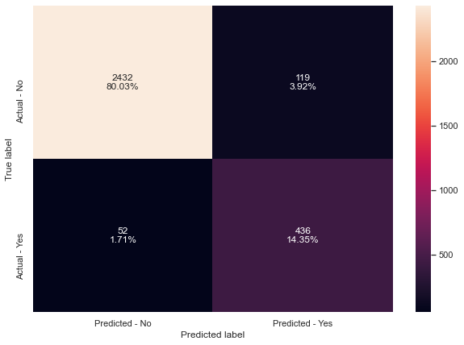

```python
draw_confusion_matrix(rf_tuned_gs,y_test)
```

```python
rf_tuned_gs_score = get_metrics_score(rf_tuned_gs,X_train,X_test,y_train,y_test)
```

```
Accuracy on training set :  0.9636004514672686
Accuracy on test set :  0.9437314906219151
Recall on training set :  0.9648814749780509
Recall on test set :  0.8934426229508197
Precision on training set :  0.8344722854973424
Precision on test set :  0.7855855855855856
```

**Insights**

- Model shows very more overfit than weighted decision tree.
- Even though Recall test score is better than tuned desicion tree,  
  since the difference between test and training recall scores is more than Desicion tree  
  so I conclude here in this case tuned decision tree is better than tuned random forest.

Go to index

### Bagging Classifier

```python
%%time

bagging_tuned_gs_pipe = Pipeline(
            steps=[
                ("scaler", StandardScaler()),
                ("bagging_classifier", BaggingClassifier(random_state=1))
            ]
        )


# Grid of parameters to choose from
## add from article
parameters = {'bagging_classifier__max_samples': [0.6,0.7,0.8,0.9,1],
              'bagging_classifier__max_features': [0.6,0.7,0.8,0.9,1],
              'bagging_classifier__n_estimators' : [10,20,30,40,50,60],
             }

# Type of scoring used to compare parameter combinations
acc_scorer = metrics.make_scorer(metrics.recall_score)

# Run the grid search
grid_obj = GridSearchCV(bagging_tuned_gs_pipe, parameters, scoring=acc_scorer,cv=5)
grid_obj = grid_obj.fit(X_train, y_train)

# Set the clf to the best combination of parameters
bagging_tuned_gs = grid_obj.best_estimator_

# Fit the best algorithm to the data.
bagging_tuned_gs.fit(X_train, y_train)
```

```
CPU times: user 4min 16s, sys: 1.84 s, total: 4min 17s
Wall time: 4min 19s
```

```
Pipeline(steps=[('scaler', StandardScaler()),
                ('bagging_classifier',
                 BaggingClassifier(max_features=0.9, max_samples=0.9,
                                   n_estimators=60, random_state=1))])
```

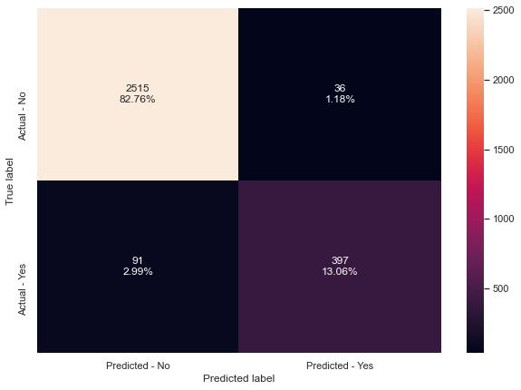

```python
draw_confusion_matrix(bagging_tuned_gs,y_test)
```

```python
y_test.value_counts()
```

```
0    2551
1     488
Name: Attrition_Flag, dtype: int64
```

```python
y_train.value_counts()
```

```
0    5949
1    1139
Name: Attrition_Flag, dtype: int64
```

```python
bagging_tuned_gs_score = get_metrics_score(bagging_tuned_gs,X_train,X_test,y_train,y_test)
```

```
Accuracy on training set :  0.9995767494356659
Accuracy on test set :  0.9582099374794341
Recall on training set :  0.9973661106233538
Recall on test set :  0.8135245901639344
Precision on training set :  1.0
Precision on test set :  0.9168591224018475
```

**Insights**

- model is overfit.
- Huge difference between training and test scores. Not ideal model to choose

### Ada Boost

```python
%%time

# Creating pipeline
adaboost_tuned_gs_pipe = make_pipeline(StandardScaler(), AdaBoostClassifier(random_state=1))

# Parameter grid to pass in GridSearchCV
param_grid = {
    "adaboostclassifier__n_estimators": np.arange(10, 60, 10),
    "adaboostclassifier__learning_rate": [0.1, 0.01, 0.05],
    "adaboostclassifier__base_estimator": [
        DecisionTreeClassifier(max_depth=1, random_state=1),
        DecisionTreeClassifier(max_depth=2, random_state=1),
        DecisionTreeClassifier(max_depth=3, random_state=1),
    ],
}

# Type of scoring used to compare parameter combinations
acc_scorer = metrics.make_scorer(metrics.recall_score)


# Run the grid search
grid_obj = GridSearchCV(adaboost_tuned_gs_pipe, param_grid, scoring=acc_scorer,cv=3)
grid_obj = grid_obj.fit(X_train, y_train)

# Set the clf to the best combination of parameters
adaboost_tuned_gs = grid_obj.best_estimator_

# Fit the best algorithm to the data.
adaboost_tuned_gs.fit(X_train, y_train)
```

```
CPU times: user 29.8 s, sys: 240 ms, total: 30 s
Wall time: 30.1 s
```

```
Pipeline(steps=[('standardscaler', StandardScaler()),
                ('adaboostclassifier',
                 AdaBoostClassifier(base_estimator=DecisionTreeClassifier(max_depth=3,
                                                                          random_state=1),
                                    learning_rate=0.1, random_state=1))])
```

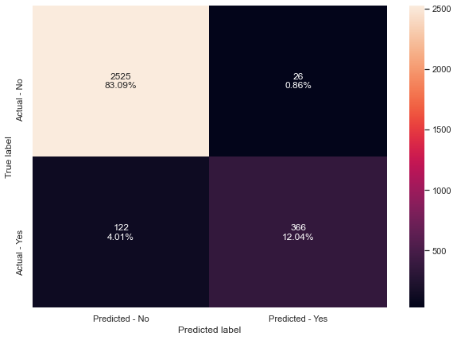

```python
draw_confusion_matrix(adaboost_tuned_gs,y_test)
```

```python
rf_tuned_gs_score = get_metrics_score(adaboost_tuned_gs,X_train,X_test,y_train,y_test)
```

```
Accuracy on training set :  0.9542889390519187
Accuracy on test set :  0.9512997696610728
Recall on training set :  0.7734855136084284
Recall on test set :  0.75
Precision on training set :  0.9303062302006336
Precision on test set :  0.9336734693877551
```

**Insights**

- Model shows less overfit. as training and test scores as near.
- but recall score is less. looks like model is underfit with respect to recall score.  
  few other models have better recall score with similar overfit so we can prefer other models ( like weighted Decision tree)in the list

Go to index

### Gradient Boost

```python
%%time

gb_tuned_gs_pipe = Pipeline(
            steps=[
                ("scaler", StandardScaler()),
                ("gradientboosting", GradientBoostingClassifier(random_state=1)),
            ]
)


param_grid={'gradientboosting__n_estimators':np.arange(50,220,50),
            'gradientboosting__learning_rate':[0.01,0.1,0.2],
            'gradientboosting__subsample':[0.7,0.9,1]}


# Type of scoring used to compare parameter combinations
acc_scorer = metrics.make_scorer(metrics.recall_score)


# Run the grid search
grid_obj = GridSearchCV(gb_tuned_gs_pipe, param_grid, scoring=acc_scorer,cv=3)
grid_obj = grid_obj.fit(X_train, y_train)

# Set the clf to the best combination of parameters
gb_tuned_gs = grid_obj.best_estimator_

# Fit the best algorithm to the data.
gb_tuned_gs.fit(X_train, y_train)
```

```
CPU times: user 1min 44s, sys: 491 ms, total: 1min 45s
Wall time: 12min 12s
```

```
Pipeline(steps=[('scaler', StandardScaler()),
                ('gradientboosting',
                 GradientBoostingClassifier(learning_rate=0.2, n_estimators=200,
                                            random_state=1, subsample=0.9))])
```

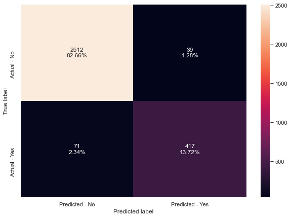

```python
draw_confusion_matrix(gb_tuned_gs,y_test)
```

```python
gb_tuned_gs_score = get_metrics_score(gb_tuned_gs,X_train,X_test,y_train,y_test)
```

```
Accuracy on training set :  0.9922404063205418
Accuracy on test set :  0.9638038828562027
Recall on training set :  0.9675153643546971
Recall on test set :  0.8545081967213115
Precision on training set :  0.9839285714285714
Precision on test set :  0.9144736842105263
```

**Insights**

- Model shows over fit. less generalization.
- Recall test score is good but the difference between test and trian score is more. so looks like less generalization and over fit .

### XG Boost

```python
%%time

xgboost_tuned_gs_pipe = Pipeline(
            steps=[
                ("scaler", StandardScaler()),
                ("xgbclassifier", XGBClassifier(random_state=1,eval_metric='logloss')),
            ]
)

#Parameter grid to pass in GridSearchCV
param_grid={'xgbclassifier__n_estimators':np.arange(50,220,50),
            'xgbclassifier__learning_rate':[0.01,0.1,0.2],
            'xgbclassifier__subsample':[0.6,0.8,1]}

# Type of scoring used to compare parameter combinations
scorer = metrics.make_scorer(metrics.recall_score)

#Calling GridSearchCV
grid_cv = GridSearchCV(estimator=xgboost_tuned_gs_pipe, param_grid=param_grid, scoring=scorer, cv=5)

#Fitting parameters in GridSeachCV
grid_cv.fit(X_train,y_train)


# Set the clf to the best combination of parameters
xgboost_tuned_gs = grid_cv.best_estimator_

# Fit the best algorithm to the data.
xgboost_tuned_gs.fit(X_train, y_train)
```

```
CPU times: user 10min 14s, sys: 4.28 s, total: 10min 19s
Wall time: 1min 20s
```

```
Pipeline(steps=[('scaler', StandardScaler()),
                ('xgbclassifier',
                 XGBClassifier(base_score=0.5, booster='gbtree',
                               colsample_bylevel=1, colsample_bynode=1,
                               colsample_bytree=1, eval_metric='logloss',
                               gamma=0, gpu_id=-1, importance_type='gain',
                               interaction_constraints='', learning_rate=0.2,
                               max_delta_step=0, max_depth=6,
                               min_child_weight=1, missing=nan,
                               monotone_constraints='()', n_estimators=50,
                               n_jobs=8, num_parallel_tree=1, random_state=1,
                               reg_alpha=0, reg_lambda=1, scale_pos_weight=1,
                               subsample=0.8, tree_method='exact',
                               validate_parameters=1, verbosity=None))])
```

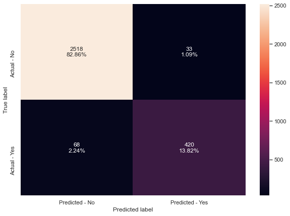

```python
draw_confusion_matrix(xgboost_tuned_gs,y_test)
```

```python
xg_tuned_gs_score = get_metrics_score(xgboost_tuned_gs,X_train,X_test,y_train,y_test)
```

```
Accuracy on training set :  0.9880079006772009
Accuracy on test set :  0.9667653833497861
Recall on training set :  0.9534679543459175
Recall on test set :  0.860655737704918
Precision on training set :  0.9713774597495528
Precision on test set :  0.9271523178807947
```

**Insights**

- Model shows over fit.
- Considerable difference between Training and test recall values. so looks like less generalization.

Go to index

### Metrics Comparision

```python
gs_tuned_list = [dTree_tuned_gs,rf_tuned_gs,bagging_tuned_gs,adaboost_tuned_gs,gb_tuned_gs,xgboost_tuned_gs]

# defining empty lists to add train and test results
acc_train = []
acc_test = []
recall_train = []
recall_test = []
precision_train = []
precision_test = []

# looping through all the models to get the metrics score - Accuracy, Recall and Precision
for name,model in gs_tuned_list:
    X_train, X_test, y_train, y_test
    model.fit(X_train, y_train)
    j = get_metrics_score(model,X_train,X_test,y_train,y_test,False)
    acc_train.append(j[0])
    acc_test.append(j[1])
    recall_train.append(j[2])
    recall_test.append(j[3])
    precision_train.append(j[4])
    precision_test.append(j[5])
```

```python
comparison_frame_gs_tuned = pd.DataFrame(
    {
        "Model": [
            "decision_tree_grid_search_tuned",
            "random_forest_grid_search_tuned",
            "bagging_classifier_grid_search_tuned",
            "adaboost_grid_search_tuned",
            "gradient_boosting_grid_search_tuned",
            "xgboost_grid_search_tuned"
        ],
        "Train_Accuracy": acc_train,
        "Test_Accuracy": acc_test,
        "Train_Recall": recall_train,
        "Test_Recall": recall_test,
        "Train_Precision": precision_train,
        "Test_Precision": precision_test
    }
)

# Sorting models in decreasing order of test recall

pd.options.display.float_format = "{:,.3f}".format
comparison_frame_gs_tuned.sort_values(by="Test_Recall", ascending=False)
```

|  | Model | Train_Accuracy | Test_Accuracy | Train_Recall | Test_Recall | Train_Precision | Test_Precision |
| --- | --- | --- | --- | --- | --- | --- | --- |
| 1 | random_forest_grid_search_tuned | 0.964 | 0.944 | 0.965 | 0.893 | 0.834 | 0.786 |
| 5 | xgboost_grid_search_tuned | 0.989 | 0.969 | 0.953 | 0.871 | 0.976 | 0.930 |
| 4 | gradient_boosting_grid_search_tuned | 0.992 | 0.964 | 0.968 | 0.857 | 0.984 | 0.915 |
| 0 | decision_tree_grid_search_tuned | 0.865 | 0.857 | 0.858 | 0.838 | 0.552 | 0.534 |
| 2 | bagging_classifier_grid_search_tuned | 1.000 | 0.959 | 0.997 | 0.816 | 1.000 | 0.917 |
| 3 | adaboost_grid_search_tuned | 0.954 | 0.951 | 0.773 | 0.750 | 0.930 | 0.934 |

### Insights from Grid Search Tuned Model Metrics

- bagging_classifier_grid_search_tuned: shows over fit.
- adaboost_grid_search_tuned: metric scores look good but recall score is less than other models.
- **From the above list,xgboost_grid_search_tuned shows up good results both for Recall and Precision**

## Hyperparameter tuning using random search

### Decision Tree

```python
%%time

dTree_tuned_rs_pipe = Pipeline(
            steps=[
                ("scaler", StandardScaler()),
                ("decision_tree", DecisionTreeClassifier(random_state=1)),
            ]
        )

# Grid of parameters to choose
parameters = {'decision_tree__class_weight': [{0: 0.2, 1: 0.8}],
              'decision_tree__max_depth': sp_randint(1,10),
              'decision_tree__min_samples_leaf': sp_randint(10,40),
              'decision_tree__max_leaf_nodes' : sp_randint(2,20),
              'decision_tree__min_impurity_decrease':[0.001,0.01,0.1]
             }

# Type of scoring used to compare parameter combinations
acc_scorer = metrics.make_scorer(metrics.recall_score)

# Run the grid search
rand_obj = RandomizedSearchCV(estimator=dTree_tuned_rs_pipe, param_distributions=parameters, n_iter=50, scoring=scorer, cv=3, random_state=1)
rand_obj = rand_obj.fit(X_train, y_train)

# Set the clf to the best combination of parameters
dTree_tuned_rs = rand_obj.best_estimator_

# Fit the best algorithm to the data.
dTree_tuned_rs.fit(X_train, y_train)
```

```
CPU times: user 3.56 s, sys: 117 ms, total: 3.68 s
Wall time: 2.56 s
```

```
Pipeline(steps=[('scaler', StandardScaler()),
                ('decision_tree',
                 DecisionTreeClassifier(class_weight={0: 0.2, 1: 0.8},
                                        max_depth=9, max_leaf_nodes=17,
                                        min_impurity_decrease=0.001,
                                        min_samples_leaf=37, random_state=1))])
```

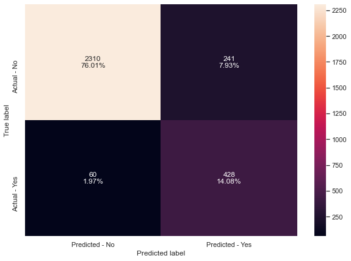

```python
draw_confusion_matrix(dTree_tuned_rs,y_test)
```

```python
dTree_tuned_rs_score = get_metrics_score(dTree_tuned_rs,X_train,X_test,y_train,y_test)
```

```
Accuracy on training set :  0.9073081264108352
Accuracy on test set :  0.9009542612701547
Recall on training set :  0.8981562774363476
Recall on test set :  0.8770491803278688
Precision on training set :  0.6540920716112532
Precision on test set :  0.6397608370702541
```

Go to index

### Random Forest

```python
%%time

rf_tuned_rs_pipe = Pipeline(
            steps=[
                ("scaler", StandardScaler()),
                ("rf_tree", RandomForestClassifier(random_state=1))
            ]
        )



# Grid of parameters to choose
parameters = {
    'rf_tree__class_weight': [{0: 0.2, 1: 0.8}],
    'rf_tree__n_estimators': sp_randint(50,150),
    'rf_tree__min_samples_leaf': sp_randint(5, 10),

}

# Type of scoring used to compare parameter combinations
acc_scorer = metrics.make_scorer(metrics.recall_score)

# Run the grid search
rand_obj = RandomizedSearchCV(estimator=rf_tuned_rs_pipe, param_distributions=parameters, n_iter=50, scoring=scorer, cv=3, random_state=1)
rand_obj = rand_obj.fit(X_train, y_train)

# Set the clf to the best combination of parameters
rf_tuned_rs = rand_obj.best_estimator_

# Fit the best algorithm to the data.
rf_tuned_rs.fit(X_train, y_train)
```

```
CPU times: user 1min, sys: 471 ms, total: 1min
Wall time: 14min 23s
```

```
Pipeline(steps=[('scaler', StandardScaler()),
                ('rf_tree',
                 RandomForestClassifier(class_weight={0: 0.2, 1: 0.8},
                                        min_samples_leaf=9, n_estimators=93,
                                        random_state=1))])
```

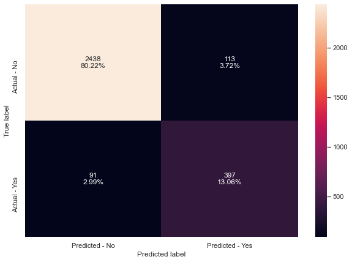

```python
draw_confusion_matrix(rf_tuned_rs,y_test)
```

```python
rf_tuned_rs_score = get_metrics_score(rf_tuned_rs,X_train,X_test,y_train,y_test)
```

```
Accuracy on training set :  0.9593679458239278
Accuracy on test set :  0.932872655478776
Recall on training set :  0.935908691834943
Recall on test set :  0.8135245901639344
Precision on training set :  0.8321623731459797
Precision on test set :  0.7784313725490196
```

### Bagging Classifier

```python
%%time

bagging_tuned_rs_pipe = Pipeline(
            steps=[
                ("scaler", StandardScaler()),
                ("bagging_classifier", BaggingClassifier(random_state=1))
            ]
        )


# Grid of parameters to choose from
## add from article
parameters = {'bagging_classifier__max_samples': [0.6,0.7,0.8,0.9,1],
              'bagging_classifier__max_features': [0.6,0.7,0.8,0.9,1],
              'bagging_classifier__n_estimators' : [10,20,30,40,50,60],
             }

# Type of scoring used to compare parameter combinations
acc_scorer = metrics.make_scorer(metrics.recall_score)

# Run the grid search
rand_obj = RandomizedSearchCV(estimator=bagging_tuned_rs_pipe, param_distributions=parameters, n_iter=50, scoring=scorer, cv=3, random_state=1)
rand_obj = rand_obj.fit(X_train, y_train)

# Set the clf to the best combination of parameters
bagging_tuned_rs = rand_obj.best_estimator_

# Fit the best algorithm to the data.
bagging_tuned_rs.fit(X_train, y_train)
```

```
CPU times: user 45.6 s, sys: 532 ms, total: 46.1 s
Wall time: 46.4 s
```

```
Pipeline(steps=[('scaler', StandardScaler()),
                ('bagging_classifier',
                 BaggingClassifier(max_features=0.9, max_samples=0.9,
                                   n_estimators=50, random_state=1))])
```

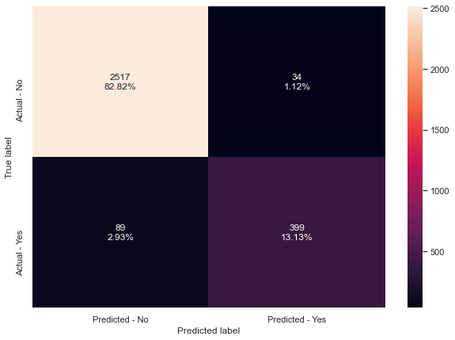

```python
draw_confusion_matrix(bagging_tuned_rs,y_test)
```

```python
bagging_tuned_rs_score = get_metrics_score(bagging_tuned_rs,X_train,X_test,y_train,y_test)
```

```
Accuracy on training set :  0.9995767494356659
Accuracy on test set :  0.9595261599210266
Recall on training set :  0.9973661106233538
Recall on test set :  0.8176229508196722
Precision on training set :  1.0
Precision on test set :  0.9214780600461894
```

### Ada boost

```python
%%time

# Creating pipeline
adaboost_tuned_rs_pipe = make_pipeline(StandardScaler(), AdaBoostClassifier(random_state=1))

# Parameter grid to pass in GridSearchCV
param_grid = {
    "adaboostclassifier__n_estimators": np.arange(10, 110, 10),
    "adaboostclassifier__learning_rate": [0.1, 0.01, 0.2, 0.05, 1],
    "adaboostclassifier__base_estimator": [
        DecisionTreeClassifier(max_depth=1, random_state=1),
        DecisionTreeClassifier(max_depth=2, random_state=1),
        DecisionTreeClassifier(max_depth=3, random_state=1),
    ],
}
# Type of scoring used to compare parameter combinations
scorer = metrics.make_scorer(metrics.recall_score)

#Calling RandomizedSearchCV
rand_cv = RandomizedSearchCV(estimator=adaboost_tuned_rs_pipe, param_distributions=param_grid, n_iter=50, scoring=scorer, cv=3, random_state=1)

#Fitting parameters in RandomizedSearchCV
rand_cv.fit(X_train,y_train)


# Set the clf to the best combination of parameters
adaboost_tuned_rs = rand_cv.best_estimator_

# Fit the best algorithm to the data.
adaboost_tuned_rs.fit(X_train, y_train)
```

```
CPU times: user 1min, sys: 418 ms, total: 1min
Wall time: 1min
```

```
Pipeline(steps=[('standardscaler', StandardScaler()),
                ('adaboostclassifier',
                 AdaBoostClassifier(base_estimator=DecisionTreeClassifier(max_depth=2,
                                                                          random_state=1),
                                    learning_rate=1, random_state=1))])
```

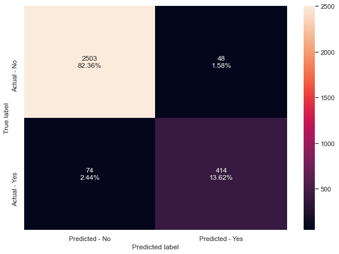

```python
draw_confusion_matrix(adaboost_tuned_rs,y_test)
```

```python
adaboost_tuned_rs_score = get_metrics_score(adaboost_tuned_rs,X_train,X_test,y_train,y_test)
```

```
Accuracy on training set :  0.9696670428893905
Accuracy on test set :  0.9598552155314248
Recall on training set :  0.884108867427568
Recall on test set :  0.8483606557377049
Precision on training set :  0.9238532110091743
Precision on test set :  0.8961038961038961
```

### Gradient boost

```python
%%time
gb_tuned_rs_pipe = Pipeline(
            steps=[
                ("scaler", StandardScaler()),
                ("gradientboosting", GradientBoostingClassifier(random_state=1)),
            ]
)


param_grid={'gradientboosting__n_estimators':np.arange(50,220,50),
            'gradientboosting__learning_rate':[0.01,0.1,0.2],
            'gradientboosting__subsample':[0.7,0.9,1]}


# Type of scoring used to compare parameter combinations
acc_scorer = metrics.make_scorer(metrics.recall_score)



#Calling RandomizedSearchCV
randomized_cv = RandomizedSearchCV(estimator=gb_tuned_rs_pipe, param_distributions=param_grid, n_iter=50, scoring=acc_scorer, cv=5, random_state=1)

#Fitting parameters in RandomizedSearchCV
randomized_cv.fit(X_train,y_train)


# Set the clf to the best combination of parameters
gb_tuned_rs = randomized_cv.best_estimator_

# Fit the best algorithm to the data.
gb_tuned_rs.fit(X_train, y_train)
```

```
CPU times: user 3min 25s, sys: 1 s, total: 3min 26s
Wall time: 3min 26s
```

```
Pipeline(steps=[('scaler', StandardScaler()),
                ('gradientboosting',
                 GradientBoostingClassifier(learning_rate=0.2, n_estimators=200,
                                            random_state=1, subsample=0.9))])
```

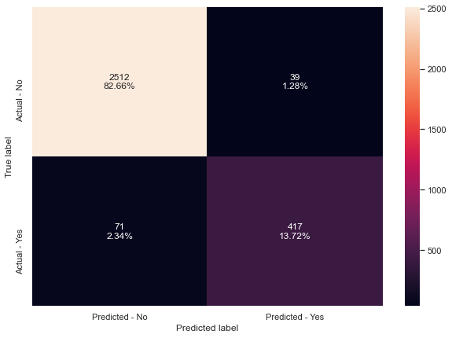

```python
draw_confusion_matrix(gb_tuned_rs,y_test)
```

```python
xgb_tuned_rs_score = get_metrics_score(gb_tuned_rs,X_train,X_test,y_train,y_test)
```

```
Accuracy on training set :  0.9922404063205418
Accuracy on test set :  0.9638038828562027
Recall on training set :  0.9675153643546971
Recall on test set :  0.8545081967213115
Precision on training set :  0.9839285714285714
Precision on test set :  0.9144736842105263
```

### XG boost

```python
%%time

#Creating pipeline
xgb_tuned_rs_pipe=make_pipeline(StandardScaler(),XGBClassifier(random_state=1,eval_metric='logloss', n_estimators = 50))

#Parameter grid to pass in GridSearchCV
param_grid={'xgbclassifier__n_estimators':np.arange(50,300,50),
            'xgbclassifier__learning_rate':[0.01,0.1,0.2,0.05],
            'xgbclassifier__subsample':[0.7,0.8,0.9,1],
           'xgbclassifier__max_depth':np.arange(1,10,1),
            'xgbclassifier__reg_lambda':[0,1,2,5,10]}





# Type of scoring used to compare parameter combinations
scorer = metrics.make_scorer(metrics.recall_score)

#Calling RandomizedSearchCV
randomized_cv = RandomizedSearchCV(estimator=xgb_tuned_rs_pipe, param_distributions=param_grid, n_iter=50, scoring=scorer, cv=5, random_state=1)

#Fitting parameters in RandomizedSearchCV
randomized_cv.fit(X_train,y_train)


# Set the clf to the best combination of parameters
xgb_tuned_rs = randomized_cv.best_estimator_

# Fit the best algorithm to the data.
xgb_tuned_rs.fit(X_train, y_train)
```

```
CPU times: user 13min 6s, sys: 4.35 s, total: 13min 10s
Wall time: 1min 41s
```

```
Pipeline(steps=[('standardscaler', StandardScaler()),
                ('xgbclassifier',
                 XGBClassifier(base_score=0.5, booster='gbtree',
                               colsample_bylevel=1, colsample_bynode=1,
                               colsample_bytree=1, eval_metric='logloss',
                               gamma=0, gpu_id=-1, importance_type='gain',
                               interaction_constraints='', learning_rate=0.2,
                               max_delta_step=0, max_depth=3,
                               min_child_weight=1, missing=nan,
                               monotone_constraints='()', n_estimators=200,
                               n_jobs=8, num_parallel_tree=1, random_state=1,
                               reg_alpha=0, reg_lambda=1, scale_pos_weight=1,
                               subsample=0.9, tree_method='exact',
                               validate_parameters=1, verbosity=None))])
```

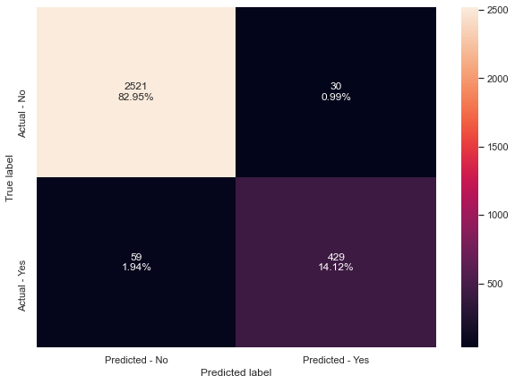

```python
draw_confusion_matrix(xgb_tuned_rs,y_test)
```

```python
xgb_tuned_rs_score = get_metrics_score(xgb_tuned_rs,X_train,X_test,y_train,y_test)
```

```
Accuracy on training set :  0.9873024830699775
Accuracy on test set :  0.970714050674564
Recall on training set :  0.9490781387181738
Recall on test set :  0.8790983606557377
Precision on training set :  0.9712488769092543
Precision on test set :  0.934640522875817
```

Go to index

### Metric Comparision

```python
rs_tuned_list = [dTree_tuned_rs,rf_tuned_rs,bagging_tuned_rs,adaboost_tuned_rs,gb_tuned_rs,xgb_tuned_rs]

# defining empty lists to add train and test results
acc_train = []
acc_test = []
recall_train = []
recall_test = []
precision_train = []
precision_test = []

# looping through all the models to get the metrics score - Accuracy, Recall and Precision
for name,model in rs_tuned_list:
    X_train, X_test, y_train, y_test
    model.fit(X_train, y_train)
    j = get_metrics_score(model,X_train,X_test,y_train,y_test,False)
    acc_train.append(j[0])
    acc_test.append(j[1])
    recall_train.append(j[2])
    recall_test.append(j[3])
    precision_train.append(j[4])
    precision_test.append(j[5])
```

```python
comparison_frame_rs_tuned = pd.DataFrame(
    {
        "Model": [
            "decision_tree_random_search_tuned",
            "random_forest_random_search_tuned",
            "bagging_classifier_random_search_tuned",
            "adaboost_random_search_tuned",
            "gradient_boosting_random_search_tuned",
            "xgboost_random_search_tuned"
        ],
        "Train_Accuracy": acc_train,
        "Test_Accuracy": acc_test,
        "Train_Recall": recall_train,
        "Test_Recall": recall_test,
        "Train_Precision": precision_train,
        "Test_Precision": precision_test
    }
)

# Sorting models in decreasing order of test recall

pd.options.display.float_format = "{:,.3f}".format
comparison_frame_rs_tuned.sort_values(by="Test_Recall", ascending=False)
```

|  | Model | Train_Accuracy | Test_Accuracy | Train_Recall | Test_Recall | Train_Precision | Test_Precision |
| --- | --- | --- | --- | --- | --- | --- | --- |
| 5 | xgboost_random_search_tuned | 0.987 | 0.971 | 0.949 | 0.879 | 0.971 | 0.935 |
| 0 | decision_tree_random_search_tuned | 0.907 | 0.901 | 0.898 | 0.877 | 0.654 | 0.640 |
| 4 | gradient_boosting_random_search_tuned | 0.992 | 0.964 | 0.968 | 0.857 | 0.984 | 0.915 |
| 3 | adaboost_random_search_tuned | 0.970 | 0.960 | 0.884 | 0.848 | 0.924 | 0.896 |
| 2 | bagging_classifier_random_search_tuned | 1.000 | 0.959 | 0.997 | 0.816 | 1.000 | 0.921 |
| 1 | random_forest_random_search_tuned | 0.959 | 0.933 | 0.936 | 0.811 | 0.832 | 0.781 |

### Insights from Random Search Tuned Model Metrics

- xgboost_random_search_tuned test recall is good but there is comparitively more difference between test recall and training recall here so we can prefer using other models. This difference shows that some noise is captured.
- **decision_tree_random_search_tuned : looks good over all other models**

  ```
    - no over fit
    - good test recall
  ```

## Model Performances

```python
comparison_frame_all_models = pd.concat([comparison_frame_lr_models,comparison_frame_models,comparison_frame_gs_tuned,comparison_frame_rs_tuned], ignore_index=True)

comparison_frame_all_models
```

|  | Model | Train_Accuracy | Test_Accuracy | Train_Recall | Test_Recall | Train_Precision | Test_Precision | Cross_Validation_Scores |
| --- | --- | --- | --- | --- | --- | --- | --- | --- |
| 0 | Simple Logistic Regression | 0.889 | 0.886 | 0.430 | 0.410 | 0.784 | 0.772 | 0.431 |
| 1 | Logistic Regression with Upsampling | 0.919 | 0.886 | 0.875 | 0.469 | 0.961 | 0.727 | 0.873 |
| 2 | Logistic Regression with DownSampling | 0.889 | 0.887 | 0.453 | 0.436 | 0.793 | 0.758 | 0.447 |
| 3 | Logistic Regression with Upsampling,Regulariza... | 0.919 | 0.886 | 0.874 | 0.467 | 0.960 | 0.728 | 0.873 |
| 4 | decision_tree | 1.000 | 0.927 | 1.000 | 0.752 | 1.000 | 0.783 | 0.731 |
| 5 | random_forest | 1.000 | 0.945 | 1.000 | 0.715 | 1.000 | 0.928 | 0.673 |
| 6 | bagging_classifier | 0.996 | 0.950 | 0.982 | 0.779 | 0.994 | 0.896 | 0.747 |
| 7 | gradient_boosting | 0.964 | 0.959 | 0.828 | 0.797 | 0.938 | 0.937 | 0.768 |
| 8 | adaboost | 0.940 | 0.935 | 0.759 | 0.727 | 0.851 | 0.847 | 0.751 |
| 9 | xgboost | 1.000 | 0.968 | 1.000 | 0.875 | 1.000 | 0.920 | 0.819 |
| 10 | decision_tree_grid_search_tuned | 0.865 | 0.857 | 0.858 | 0.838 | 0.552 | 0.534 | nan |
| 11 | random_forest_grid_search_tuned | 0.964 | 0.944 | 0.965 | 0.893 | 0.834 | 0.786 | nan |
| 12 | bagging_classifier_grid_search_tuned | 1.000 | 0.959 | 0.997 | 0.816 | 1.000 | 0.917 | nan |
| 13 | adaboost_grid_search_tuned | 0.954 | 0.951 | 0.773 | 0.750 | 0.930 | 0.934 | nan |
| 14 | gradient_boosting_grid_search_tuned | 0.992 | 0.964 | 0.968 | 0.857 | 0.984 | 0.915 | nan |
| 15 | xgboost_grid_search_tuned | 0.989 | 0.969 | 0.953 | 0.871 | 0.976 | 0.930 | nan |
| 16 | decision_tree_random_search_tuned | 0.907 | 0.901 | 0.898 | 0.877 | 0.654 | 0.640 | nan |
| 17 | random_forest_random_search_tuned | 0.959 | 0.933 | 0.936 | 0.811 | 0.832 | 0.781 | nan |
| 18 | bagging_classifier_random_search_tuned | 1.000 | 0.959 | 0.997 | 0.816 | 1.000 | 0.921 | nan |
| 19 | adaboost_random_search_tuned | 0.970 | 0.960 | 0.884 | 0.848 | 0.924 | 0.896 | nan |
| 20 | gradient_boosting_random_search_tuned | 0.992 | 0.964 | 0.968 | 0.857 | 0.984 | 0.915 | nan |
| 21 | xgboost_random_search_tuned | 0.987 | 0.971 | 0.949 | 0.879 | 0.971 | 0.935 | nan |

**Insights from all models**

```python
# sorted on Test recall metric in descending order
comparison_frame_all_models.sort_values(by="Test_Recall", ascending=False)
```

|  | Model | Train_Accuracy | Test_Accuracy | Train_Recall | Test_Recall | Train_Precision | Test_Precision | Cross_Validation_Scores |
| --- | --- | --- | --- | --- | --- | --- | --- | --- |
| 11 | random_forest_grid_search_tuned | 0.964 | 0.944 | 0.965 | 0.893 | 0.834 | 0.786 | nan |
| 21 | xgboost_random_search_tuned | 0.987 | 0.971 | 0.949 | 0.879 | 0.971 | 0.935 | nan |
| 16 | decision_tree_random_search_tuned | 0.907 | 0.901 | 0.898 | 0.877 | 0.654 | 0.640 | nan |
| 9 | xgboost | 1.000 | 0.968 | 1.000 | 0.875 | 1.000 | 0.920 | 0.819 |
| 15 | xgboost_grid_search_tuned | 0.989 | 0.969 | 0.953 | 0.871 | 0.976 | 0.930 | nan |
| 14 | gradient_boosting_grid_search_tuned | 0.992 | 0.964 | 0.968 | 0.857 | 0.984 | 0.915 | nan |
| 20 | gradient_boosting_random_search_tuned | 0.992 | 0.964 | 0.968 | 0.857 | 0.984 | 0.915 | nan |
| 19 | adaboost_random_search_tuned | 0.970 | 0.960 | 0.884 | 0.848 | 0.924 | 0.896 | nan |
| 10 | decision_tree_grid_search_tuned | 0.865 | 0.857 | 0.858 | 0.838 | 0.552 | 0.534 | nan |
| 18 | bagging_classifier_random_search_tuned | 1.000 | 0.959 | 0.997 | 0.816 | 1.000 | 0.921 | nan |
| 12 | bagging_classifier_grid_search_tuned | 1.000 | 0.959 | 0.997 | 0.816 | 1.000 | 0.917 | nan |
| 17 | random_forest_random_search_tuned | 0.959 | 0.933 | 0.936 | 0.811 | 0.832 | 0.781 | nan |
| 7 | gradient_boosting | 0.964 | 0.959 | 0.828 | 0.797 | 0.938 | 0.937 | 0.768 |
| 6 | bagging_classifier | 0.996 | 0.950 | 0.982 | 0.779 | 0.994 | 0.896 | 0.747 |
| 4 | decision_tree | 1.000 | 0.927 | 1.000 | 0.752 | 1.000 | 0.783 | 0.731 |
| 13 | adaboost_grid_search_tuned | 0.954 | 0.951 | 0.773 | 0.750 | 0.930 | 0.934 | nan |
| 8 | adaboost | 0.940 | 0.935 | 0.759 | 0.727 | 0.851 | 0.847 | 0.751 |
| 5 | random_forest | 1.000 | 0.945 | 1.000 | 0.715 | 1.000 | 0.928 | 0.673 |
| 1 | Logistic Regression with Upsampling | 0.919 | 0.886 | 0.875 | 0.469 | 0.961 | 0.727 | 0.873 |
| 3 | Logistic Regression with Upsampling,Regulariza... | 0.919 | 0.886 | 0.874 | 0.467 | 0.960 | 0.728 | 0.873 |
| 2 | Logistic Regression with DownSampling | 0.889 | 0.887 | 0.453 | 0.436 | 0.793 | 0.758 | 0.447 |
| 0 | Simple Logistic Regression | 0.889 | 0.886 | 0.430 | 0.410 | 0.784 | 0.772 | 0.431 |

**Final short listed model analysis**

```python
comparison_frame_all_models[comparison_frame_all_models['Model'].isin(['gradient_boosting','decision_tree_grid_search_tuned','decision_tree_random_search_tuned','adaboost_random_search_tuned','xgboost_random_search_tuned'])]
```

|  | Model | Train_Accuracy | Test_Accuracy | Train_Recall | Test_Recall | Train_Precision | Test_Precision | Cross_Validation_Scores |
| --- | --- | --- | --- | --- | --- | --- | --- | --- |
| 7 | gradient_boosting | 0.964 | 0.959 | 0.828 | 0.797 | 0.938 | 0.937 | 0.768 |
| 10 | decision_tree_grid_search_tuned | 0.865 | 0.857 | 0.858 | 0.838 | 0.552 | 0.534 | nan |
| 16 | decision_tree_random_search_tuned | 0.907 | 0.901 | 0.898 | 0.877 | 0.654 | 0.640 | nan |
| 19 | adaboost_random_search_tuned | 0.970 | 0.960 | 0.884 | 0.848 | 0.924 | 0.896 | nan |
| 21 | xgboost_random_search_tuned | 0.987 | 0.971 | 0.949 | 0.879 | 0.971 | 0.935 | nan |

- xgboost_random_search_tuned has highest recall score but looks like there is considereable difference between train and test recall which means some noise is captured so this model is not selected.
- **decision_tree_random_search_tuned has better recall score after xgboost. recall and accuracy are good. Precision score is low but precision is not important score in this usecase so we can go with thie model for our consideration.**
- adaboost_random_search_tuned - looks like model captured some noice. more difference between train and test recall when compared to decision_tree_random_search_tuned.

**So decision_tree_random_search_tuned model is selected**

**Grid search and Random search comparition**

Other algorithms which have great improvement in time with Random search are RandomForest,Bagging Classifier.

but we see more execution time with Random search for Adaboost, Gradient boost, xgboost. this might be because of more number of iterations than the possible combinations in Grid search.

Go to index

### Feature importance

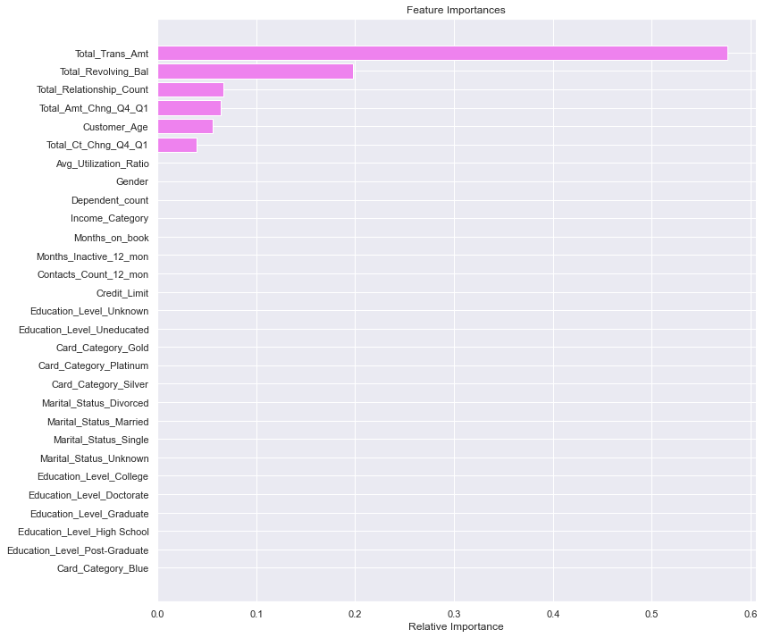

```python
importances = dTree_tuned_rs['decision_tree'].feature_importances_
indices = np.argsort(importances)
feature_names = list(X.columns)

plt.figure(figsize=(12,12))
plt.title('Feature Importances')
plt.barh(range(len(indices)), importances[indices], color='violet', align='center')
plt.yticks(range(len(indices)), [feature_names[i] for i in indices])
plt.xlabel('Relative Importance')
plt.show()
```

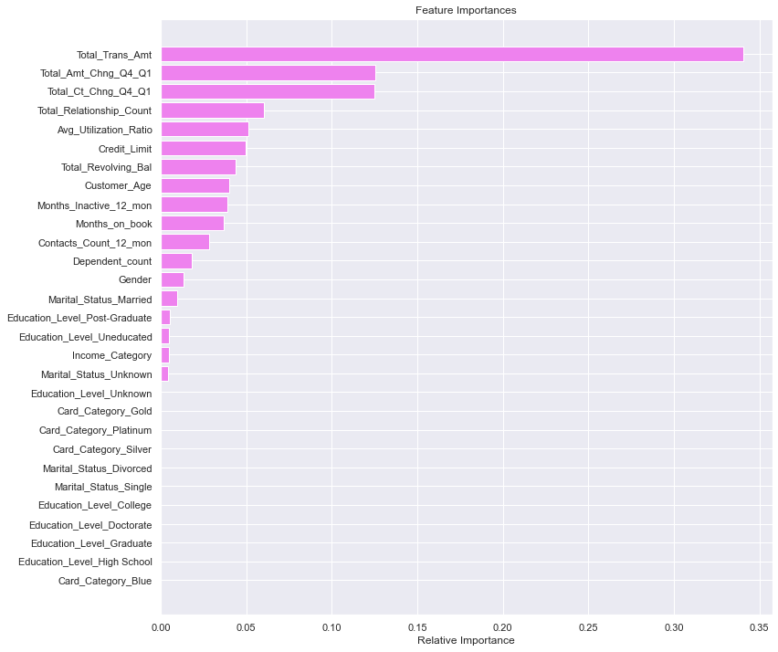

```python
importances = adaboost_tuned_rs['adaboostclassifier'].feature_importances_
indices = np.argsort(importances)
feature_names = list(X.columns)

plt.figure(figsize=(12,12))
plt.title('Feature Importances')
plt.barh(range(len(indices)), importances[indices], color='violet', align='center')
plt.yticks(range(len(indices)), [feature_names[i] for i in indices])
plt.xlabel('Relative Importance')
plt.show()
```

## Actionable Insights & Recommendations

1. From feature importance, we see Total_tans_amo, Total_Revolving_bal,Total_relationship_count are few importance varialbes that can be considered by the business.

   ```
    - Total_trans_amo is very less for Attritted customers. so Bank can consider any customer with less Total_trans_amo as targeted customers who are likely to leave the offer and act accordingly.
   ```

2. Blue card holders have lowest total_tranasaction_amount. Bank can check if it can bring any offers to reatian those users.

3.Attrision is common in all income categories.